# Filter genotypes and variants ampliseq

Alexey Larionov

27 Feb 2021

# 1 Summary

Remove genotypes (set to NA) if:  
1) genotypes gq < 20 (~12%)  
2) genotypes dp < 10 (~18.5%, +6.5% after gq filter)  
3) genotypes dp > 1000 (~2%)  
4) Alt fraction

- is > 0.2 in Hom-Ref
- is <0.2 or >0.8 in Het
- is < 0.8 in Hom-Alt

Remove variants with  
1) call_rate < 0.85  
this step **removes ~42% of all variants**  
2) uniform genotypes accross all samples  
(created by the above filtering)

In addition  
-Exclude (a small number of) genotypes with unknown alt fraction  
- remove unnecessary matrices (gt_num, gt_add, meta, gq, ref, alt); keep dp and gt_chr for later use

gq 20 filter is set arbitrary; however, it is consistent with what some othersis do  
(e.g. see Carson BMC Bioinformatics. 2014 15:125).

A small number of genotypes (~2%) was covered too high to be true (above 1000 coverage).  
These are obvious mistakes, and they have been removed too. Arbitrarily the threshold for  
max DP was set to 1000 (appr. 20 fold of average coverage).

Input data: 7,762 vars x 541 cases  
Output data: 3,769 vars x 541 cases

# 2 Start section

```r
# Time stamp
Sys.time()
```

```
## [1] "2021-02-27 17:52:14 GMT"
```

```r
# Clenan-up
rm(list=ls())
graphics.off()

# Memory
gc()
```

```
##          used (Mb) gc trigger (Mb) limit (Mb) max used (Mb)
## Ncells 415349 22.2     865952 46.3         NA   641517 34.3
## Vcells 790984  6.1    8388608 64.0      16384  1768562 13.5
```

```r
# Options
options(stringsAsFactors = F,
        warnPartialMatchArgs = T,
        warnPartialMatchAttr = T,
        warnPartialMatchDollar = T)

# Files and folders
base_folder="/Users/alexey/Documents/wecare/final_analysis_2021/reanalysis_wo_danish_2021/ampliseq/s01_ampliseq_wecare_only"
data_folder <- file.path(base_folder,"data","s07_qc_filters")
scripts_folder <- file.path(base_folder,"scripts","s07_qc_filters")
setwd(scripts_folder)

# Thresholds for genotypes
min.gq <- 20
min.dp <- 10
max.dp <- 1000
alt.fr.lo <- 0.2
alt.fr.hi <- 0.8
min.call.rate <- 0.85
```

# 3 Load data

## 3.1 Load

```r
load(file.path(data_folder, "r01_filter_variants.RData"))

# Update folders
base_folder="/Users/alexey/Documents/wecare/final_analysis_2021/reanalysis_wo_danish_2021/ampliseq/s01_ampliseq_wecare_only"
data_folder <- file.path(base_folder,"data","s07_qc_filters")
scripts_folder <- file.path(base_folder,"scripts","s07_qc_filters")

# Rename and remove some matrices
gt.mx <- gt_add.mx
rm(gt_add.mx, gt_num.mx, meta.df) # keep gt_chr.mx for TsTv ratio check later
```

## 3.2 Check data

```r
# List objects
ls()
```

```
##  [1] "alt.fr.hi"      "alt.fr.lo"      "alt.mx"         "base_folder"    "data_folder"    "dp.mx"          "fixed.df"       "gq.mx"          "gt_chr.mx"      "gt.mx"          "max.dp"         "min.call.rate"  "min.dp"         "min.gq"         "ref.mx"         "scripts_folder"
```

```r
# Check sizes
dim(gt.mx)
```

```
## [1] 7762  541
```

```r
dim(ref.mx)
```

```
## [1] 7762  541
```

```r
dim(alt.mx)
```

```
## [1] 7762  541
```

```r
dim(gq.mx)
```

```
## [1] 7762  541
```

```r
dim(dp.mx)
```

```
## [1] 7762  541
```

```r
dim(fixed.df)
```

```
## [1] 7762  110
```

```r
# Check consistence of rownames and colnames

sum(rownames(gt.mx) != rownames(gq.mx))
```

```
## [1] 0
```

```r
sum(rownames(gt.mx) != rownames(dp.mx))
```

```
## [1] 0
```

```r
sum(rownames(gt.mx) != rownames(ref.mx))
```

```
## [1] 0
```

```r
sum(rownames(gt.mx) != rownames(alt.mx))
```

```
## [1] 0
```

```r
sum(colnames(gt.mx) != colnames(gq.mx))
```

```
## [1] 0
```

```r
sum(colnames(gt.mx) != colnames(dp.mx))
```

```
## [1] 0
```

```r
sum(colnames(gt.mx) != colnames(ref.mx))
```

```
## [1] 0
```

```r
sum(colnames(gt.mx) != colnames(alt.mx))
```

```
## [1] 0
```

```r
sum(rownames(gt.mx) != rownames(fixed.df))
```

```
## [1] 0
```

# 4 Explore data before filtering

Genotypes NA rates  
Histogram of call rates per variant  
Histograms of gq and dp in non-NA genotypes

```r
gt.mx[1:5,1:5]
```

```
##              100_S8_L007 101_S528_L008 102_S466_L008 103_S147_L007 104_S325_L008
## Var000000001           0             0             0             0             0
## Var000000003           0             0             0             0             0
## Var000000004           0             2             2             2             1
## Var000000005           0             2             2             2             1
## Var000000006           0             0             0             0             0
```

```r
# Fraction of NA genotypes before filtering
sum(is.na(gt.mx))/(nrow(gt.mx)*ncol(gt.mx)) # ~2.8%
```

```
## [1] 0.02831249
```

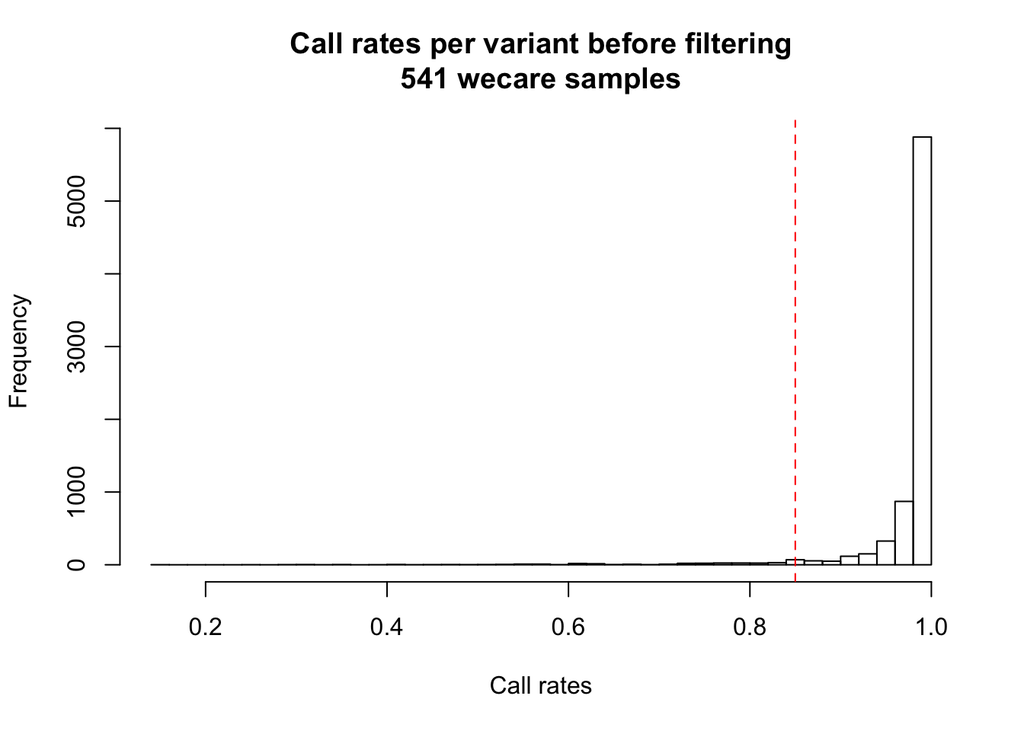

```r
# Call rates per variant before filtering
call_rate.udf <- function(x){sum(!is.na(x))/length(x)}
x <- apply(gt.mx,1,call_rate.udf)
hist(x, breaks=50, main="Call rates per variant before filtering\n541 wecare samples", xlab="Call rates")
abline(v=min.call.rate, lty=2, col="red")
```

```r
sum(x < min.call.rate)
```

```
## [1] 269
```

```r
sum(x < min.call.rate)/length(x) # Fraction of variants failing below the cut-off
```

```
## [1] 0.03465602
```

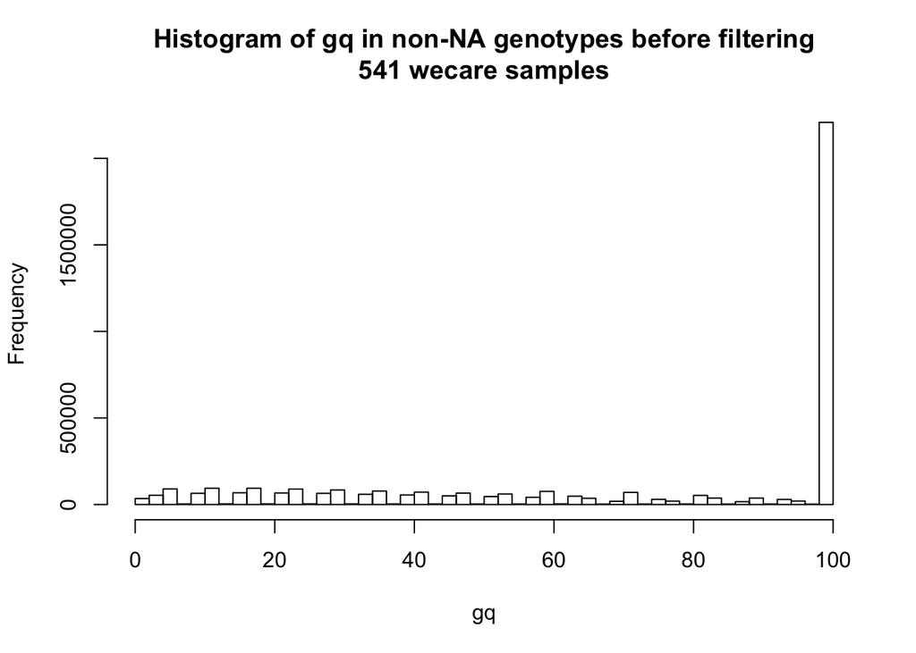

```r
# gq  before filtering (when gt is not NA !)
hist(gq.mx[!is.na(gt.mx)], breaks=50,
     main="Histogram of gq in non-NA genotypes before filtering\n541 wecare samples", xlab="gq")
```

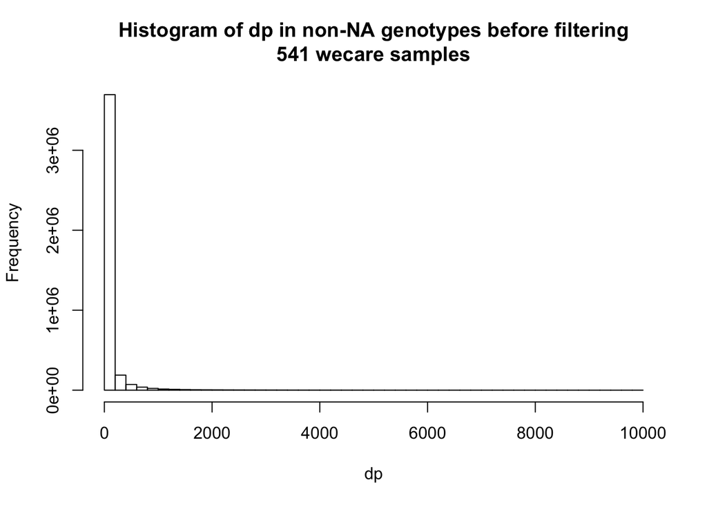

```r
# dp before filtering (when gt is not NA !)
hist(dp.mx[!is.na(gt.mx)], breaks=50,
     main="Histogram of dp in non-NA genotypes before filtering\n541 wecare samples", xlab="dp")
```

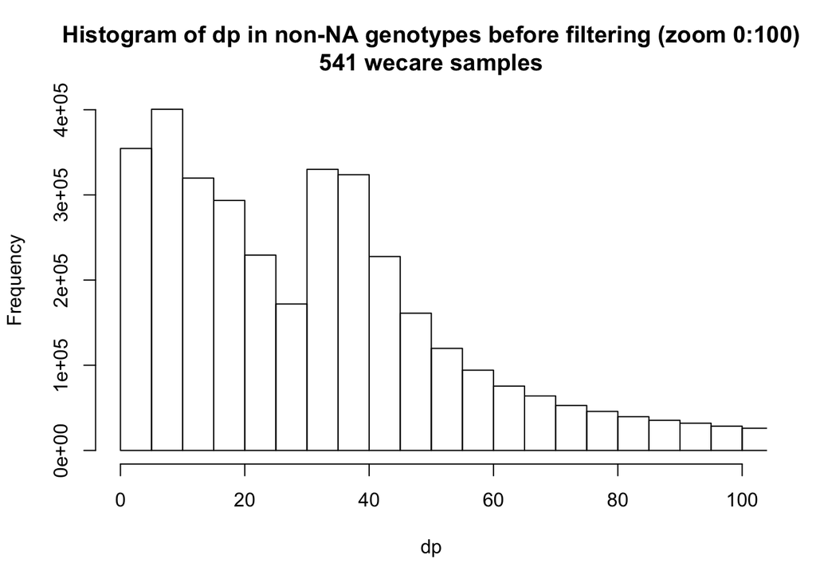

```r
hist(dp.mx[!is.na(gt.mx)], breaks=2500, xlim=c(0,100),
     main="Histogram of dp in non-NA genotypes before filtering (zoom 0:100)\n541 wecare samples", xlab="dp")
```

```r
# GQ and DP in non-NA genotypes before filtering
quantile(gq.mx[!is.na(gt.mx)], na.rm=TRUE) # median gq ~ 99
```

```
##   0%  25%  50%  75% 100%
##    0   42   99   99   99
```

```r
quantile(dp.mx[!is.na(gt.mx)], na.rm=TRUE) # median dp ~ 35
```

```
##   0%  25%  50%  75% 100%
##    0   14   35   63 9901
```

```r
mean(gq.mx[!is.na(gt.mx)], na.rm=TRUE) # mean gq ~ 72
```

```
## [1] 72.12772
```

```r
mean(dp.mx[!is.na(gt.mx)], na.rm=TRUE) # mean dp ~105
```

```
## [1] 105.0149
```

```r
# crude estimates for proportions of genotypes to be removed by filters
sum(dp.mx > max.dp, na.rm = T) / sum(!is.na(dp.mx))
```

```
## [1] 0.01591811
```

```r
sum(dp.mx < min.dp, na.rm = T) / sum(!is.na(dp.mx))
```

```
## [1] 0.1870073
```

```r
sum(gq.mx < min.gq, na.rm = T) / sum(!is.na(gq.mx))
```

```
## [1] 0.1243237
```

```r
# Clean-up
rm(x)
```

# 5 Filter out low_gq

## 5.1 Filter

Put NA to genotypes where gq < 20 : removes ~12% of non-NA genotypes

```r
# num of genotypes to be removed (in !NA gt)
format(sum(gq.mx[!is.na(gt.mx)] < min.gq, na.rm=TRUE), big.mark=",") # ~506K
```

```
## [1] "506,384"
```

```r
# Fraction of non-NA genotypes to be removed (in !NA gt)
sum(gq.mx[!is.na(gt.mx)] < min.gq, na.rm=TRUE)/sum(!is.na(gt.mx)) # ~12%
```

```
## [1] 0.124103
```

```r
# Apply filter (to gt only !)
NA -> gt.mx[ gq.mx < min.gq ]
NA -> gt_chr.mx[ gq.mx < min.gq ] # Keep gt_chr.mx for Ts/Tv later

# Clean up
rm(min.gq)
```

## 5.2 Explore data after gq filtering

```r
# Fractions of NA genotypes after gq filtering
sum(is.na(gt.mx))/(nrow(gt.mx)*ncol(gt.mx)) # ~15%
```

```
## [1] 0.1489019
```

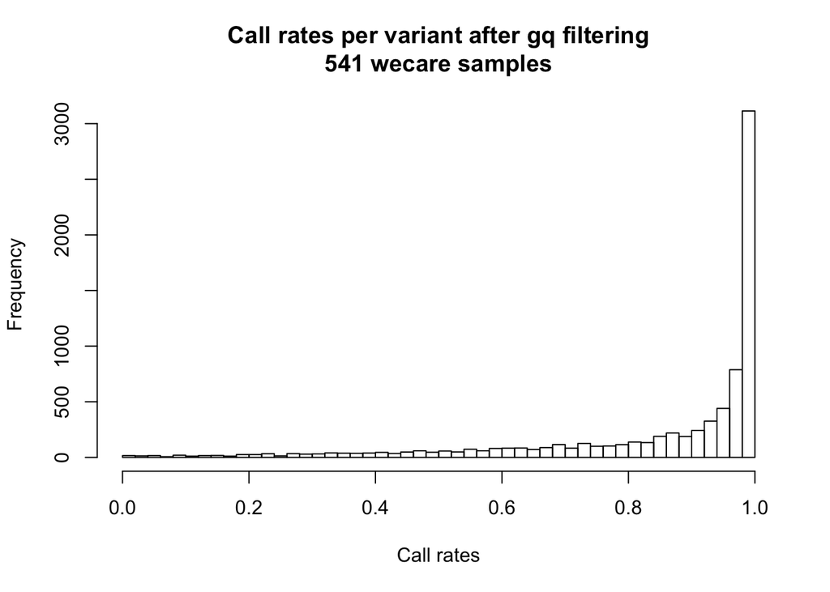

```r
# Call rates per variant after gq filtering
x <- apply(gt.mx,1,call_rate.udf)
hist(x, breaks=50, main="Call rates per variant after gq filtering\n541 wecare samples", xlab="Call rates")
```

```r
sum(x < min.call.rate)
```

```
## [1] 2344
```

```r
sum(x < min.call.rate)/length(x) # Fraction of variants to be removed
```

```
## [1] 0.301984
```

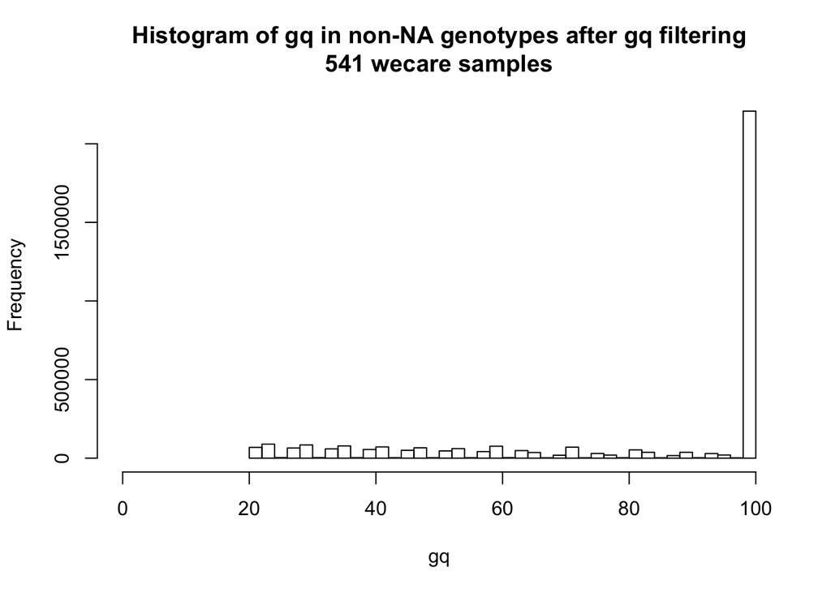

```r
# gq  after gq filtering (when gt is not NA !)
hist(gq.mx[!is.na(gt.mx)], breaks=50, xlim=c(0,100),
     main="Histogram of gq in non-NA genotypes after gq filtering\n541 wecare samples", xlab="gq")
```

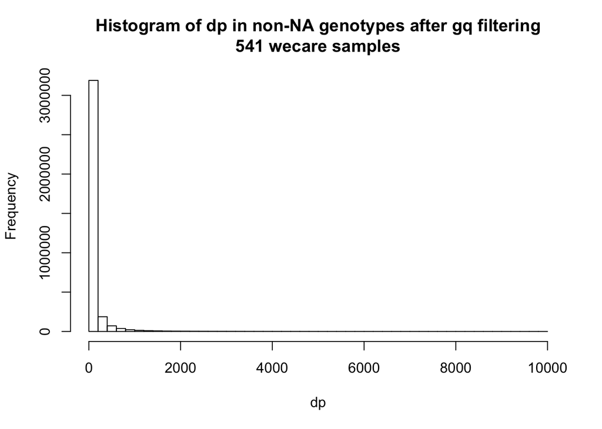

```r
# dp after gq filtering (when gt is not NA !)
hist(dp.mx[!is.na(gt.mx)], breaks=50,
     main="Histogram of dp in non-NA genotypes after gq filtering\n541 wecare samples", xlab="dp")
```

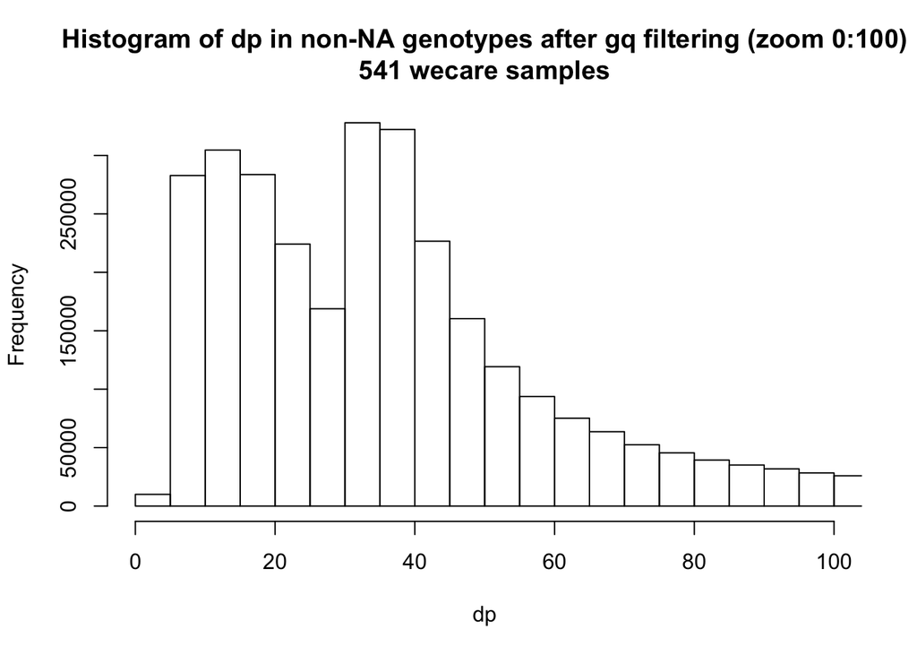

```r
hist(dp.mx[!is.na(gt.mx)], breaks=2500, xlim=c(0,100),
     main="Histogram of dp in non-NA genotypes after gq filtering (zoom 0:100)\n541 wecare samples", xlab="dp")
```

```r
# Mean GQ and DP in non-NA genotypes after gq filtering
mean(gq.mx[!is.na(gt.mx)], na.rm=TRUE) # ~ 81
```

```
## [1] 80.90272
```

```r
mean(dp.mx[!is.na(gt.mx)], na.rm=TRUE) # ~ 120
```

```
## [1] 118.7372
```

```r
# Clean-up
rm(x)
```

# 6 Filter out low dp

## 6.1 Filter

Put NA to genotypes where dp < 10 : additionally removes ~6.5% of non-NA genotypes

```r
# num of genotypes to be removed (in !NA gt after gq filtering)
format(sum(dp.mx[!is.na(gq.mx)] < min.dp, na.rm=TRUE), big.mark=",") # ~661K
```

```
## [1] "661,424"
```

```r
# Fraction of genotypes to be removed (in !NA gt after gq filtering)
sum(dp.mx[!is.na(gq.mx)] < min.dp, na.rm=TRUE)/sum(!is.na(gt.mx)) # ~18.5%
```

```
## [1] 0.1850672
```

```r
# Apply filter (to gt only !)
NA -> gt.mx[ dp.mx < min.dp ]
NA -> gt_chr.mx[ dp.mx < min.dp ]

# Clean up
rm(min.dp)
```

## 6.2 Explore data after gq_min-dp filtering

```r
# Fraction of NA genotypes after gq filtering
sum(is.na(gt.mx))/(nrow(gt.mx)*ncol(gt.mx)) # ~20%
```

```
## [1] 0.1991057
```

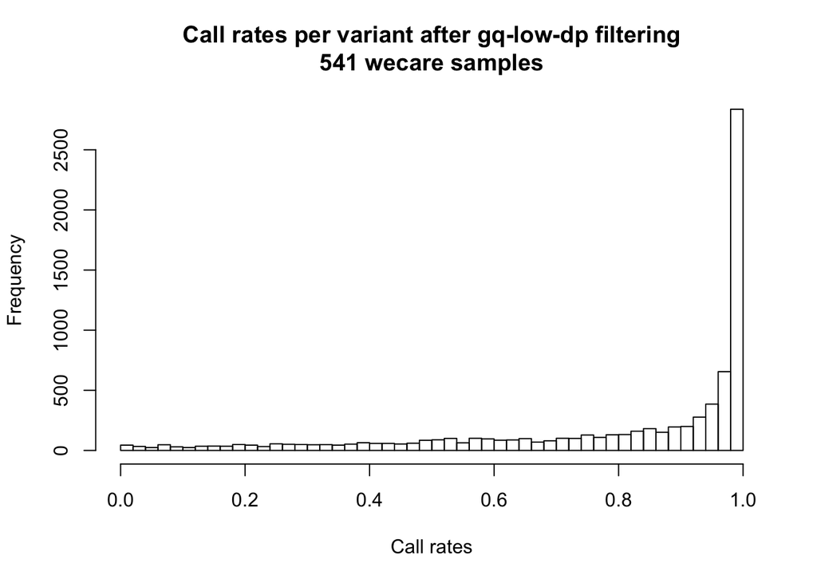

```r
# Call rates per variant after gq-dp filtering
x <- apply(gt.mx,1,call_rate.udf)
hist(x, breaks=50, main="Call rates per variant after gq-low-dp filtering\n541 wecare samples", xlab="Call rates")
```

```r
sum(x < min.call.rate)
```

```
## [1] 2970
```

```r
sum(x < min.call.rate)/length(x)
```

```
## [1] 0.3826333
```

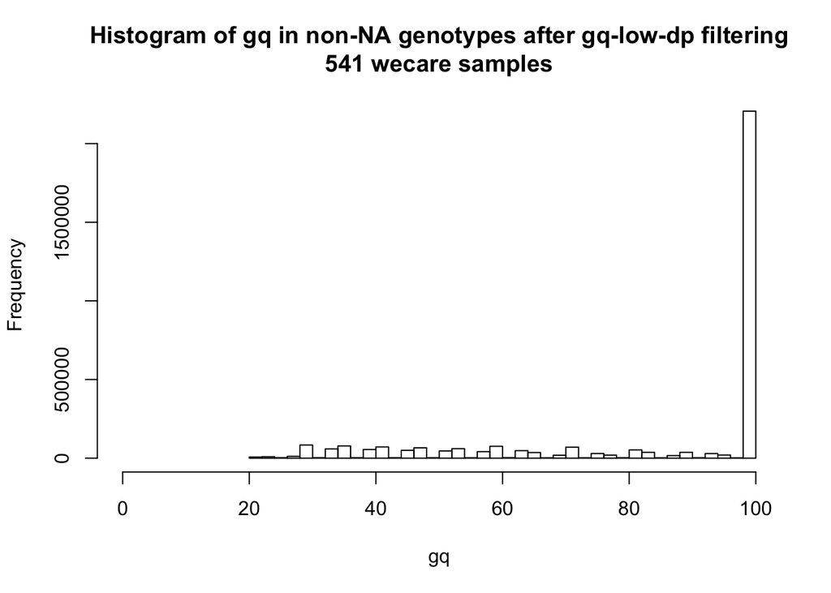

```r
# gq  after gq-dp filtering (when gt is not NA !)
hist(gq.mx[!is.na(gt.mx)], breaks=50, xlim=c(0,100),
     main="Histogram of gq in non-NA genotypes after gq-low-dp filtering\n541 wecare samples", xlab="gq")
```

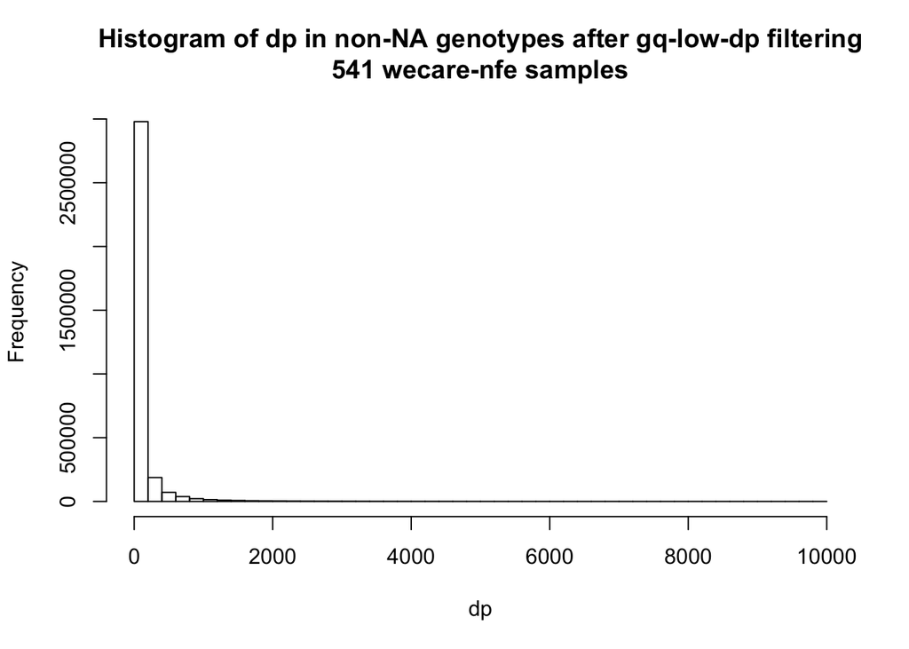

```r
# dp after gq-dp filtering (when gt is not NA !)
hist(dp.mx[!is.na(gt.mx)], breaks=50,
     main="Histogram of dp in non-NA genotypes after gq-low-dp filtering\n541 wecare-nfe samples", xlab="dp")
```

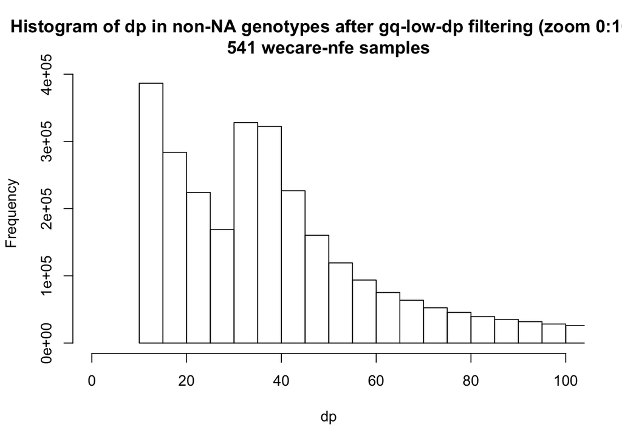

```r
hist(dp.mx[!is.na(gt.mx)], breaks=2500, xlim=c(0,100),
     main="Histogram of dp in non-NA genotypes after gq-low-dp filtering (zoom 0:100)\n541 wecare-nfe samples", xlab="dp")
```

```r
# Mean GQ and DP in non-NA genotypes after gq-dp filtering
mean(gq.mx[!is.na(gt.mx)], na.rm=TRUE) # ~ 84
```

```
## [1] 84.25469
```

```r
mean(dp.mx[!is.na(gt.mx)], na.rm=TRUE) # ~ 126
```

```
## [1] 125.6986
```

```r
# Clean-up
rm(x)
```

# 7 Filter out high_dp

## 7.1 Filter

put NA to genotypes where dp > 1000 : removes ~2% of non-NA genotypes

```r
# num of genotypes to be removed (in !NA gt after previous filtering)
format(sum(dp.mx[!is.na(gq.mx)] > max.dp, na.rm=TRUE), big.mark=",") # ~66K
```

```
## [1] "66,309"
```

```r
# Fraction of genotypes to be removed (in !NA gt after previous filtering)
sum(dp.mx[!is.na(gq.mx)] > max.dp, na.rm=TRUE)/sum(!is.na(gt.mx)) # ~2%
```

```
## [1] 0.01971634
```

```r
# Apply filter (to gt only !)
NA -> gt.mx[ dp.mx > max.dp ]
NA -> gt_chr.mx[ dp.mx > max.dp ]

# Clean up
rm(max.dp)
```

## 7.2 Explore data after gq_dp filtering

```r
# Fractions of NA genotypes after gq-dp filtering
sum(is.na(gt.mx))/(nrow(gt.mx)*ncol(gt.mx)) # ~21%
```

```
## [1] 0.2148638
```

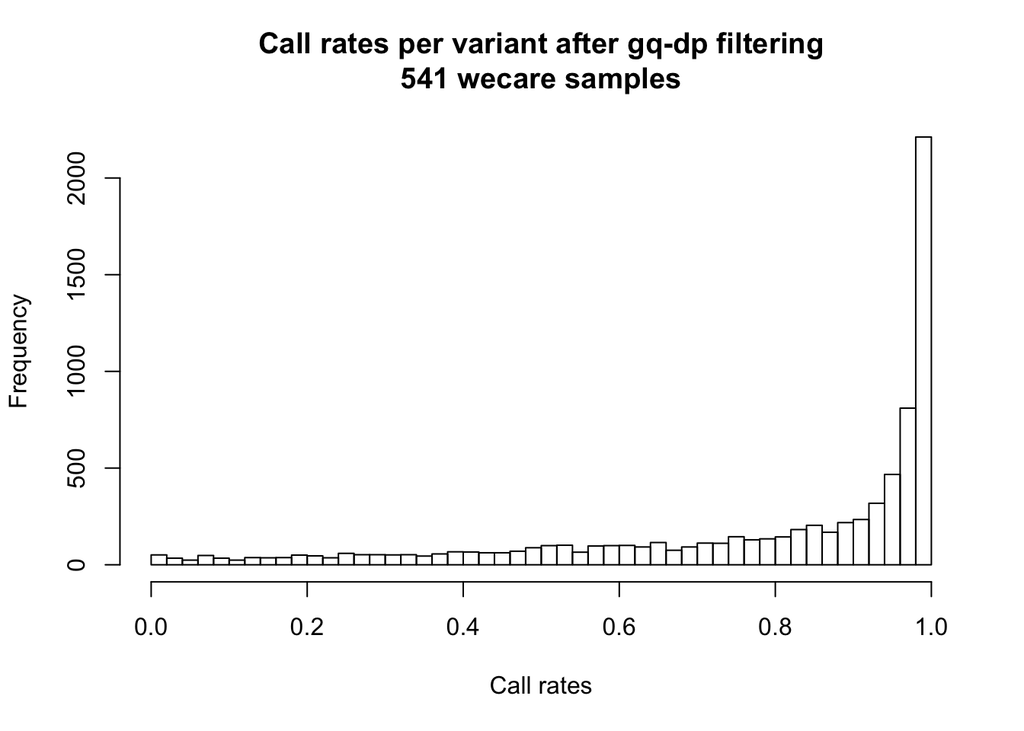

```r
# Call rates per variant after gq-dp filtering
x <- apply(gt.mx,1,call_rate.udf)
hist(x, breaks=50, main="Call rates per variant after gq-dp filtering\n541 wecare samples", xlab="Call rates")
```

```r
sum(x < min.call.rate)
```

```
## [1] 3225
```

```r
sum(x < min.call.rate)/length(x)
```

```
## [1] 0.4154857
```

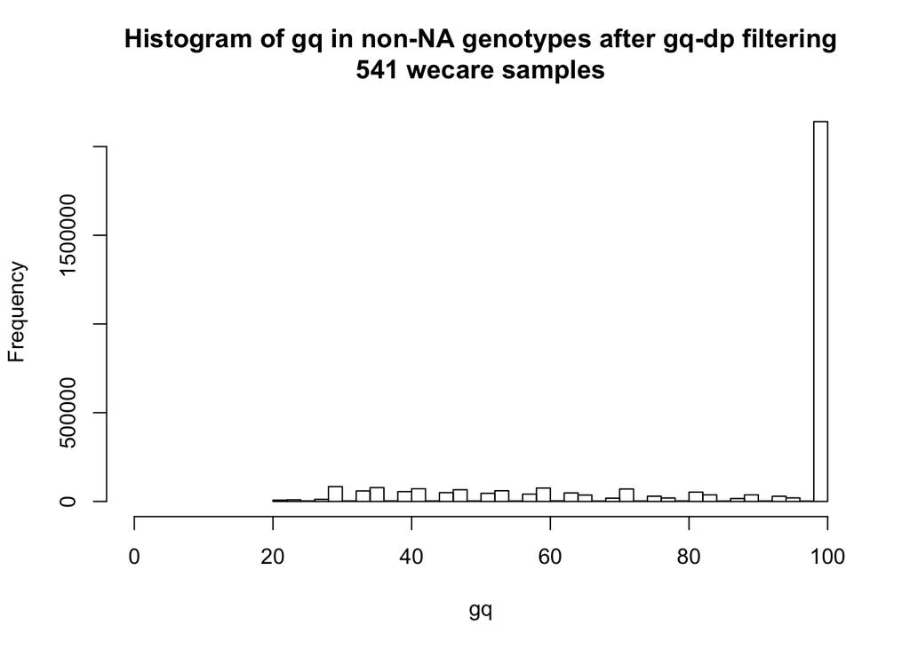

```r
# gq  after gq-dp filtering (when gt is not NA !)
hist(gq.mx[!is.na(gt.mx)], breaks=50, xlim=c(0,100),
     main="Histogram of gq in non-NA genotypes after gq-dp filtering\n541 wecare samples", xlab="gq")
```

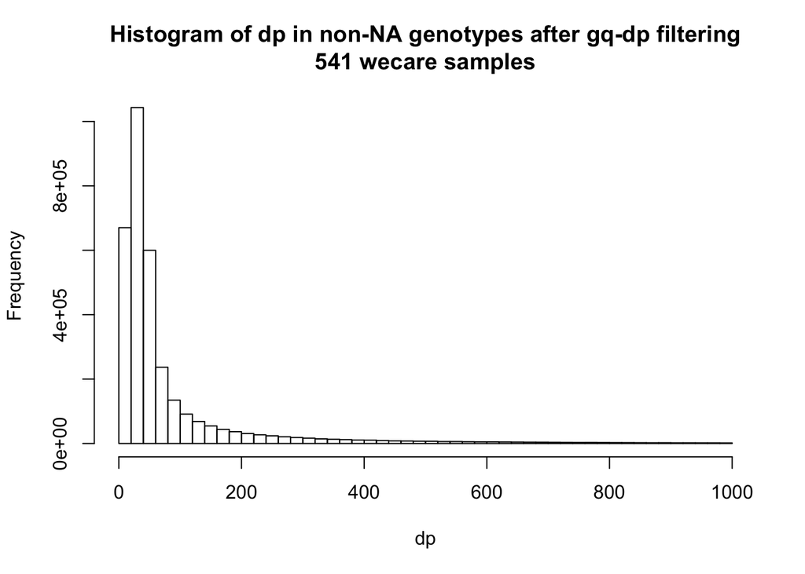

```r
# dp after gq-dp filtering (when gt is not NA !)
hist(dp.mx[!is.na(gt.mx)], breaks=50,
     main="Histogram of dp in non-NA genotypes after gq-dp filtering\n541 wecare samples", xlab="dp")
```

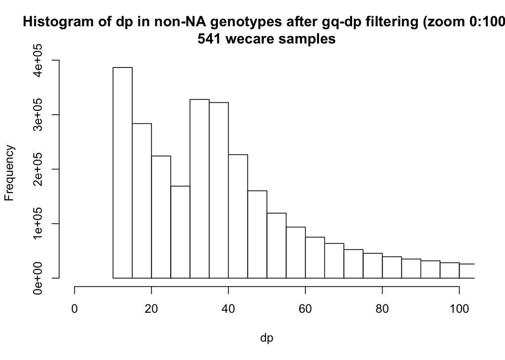

```r
hist(dp.mx[!is.na(gt.mx)], breaks=250, xlim=c(0,100),
     main="Histogram of dp in non-NA genotypes after gq-dp filtering (zoom 0:100)\n541 wecare samples", xlab="dp")
```

```r
# Mean GQ and DP in non-NA genotypes after gq-dp filtering
mean(gq.mx[!is.na(gt.mx)], na.rm=TRUE) # ~ 84
```

```
## [1] 83.95937
```

```r
mean(dp.mx[!is.na(gt.mx)], na.rm=TRUE) # ~ 83
```

```
## [1] 83.3301
```

```r
# Clean-up
rm(x)
```

# 8 Filtering by fraction of reads supporting ALT allele

## 8.1 Check Alt allele fraction in Hom-Ref, Het and Hom-Alt

Exclude (a small number of) genotypes with unknown alt fraction

```r
# Prepare alt_fraction.mx
alt_fraction.mx <- alt.mx / (alt.mx + ref.mx)
dim(alt_fraction.mx)
```

```
## [1] 7762  541
```

```r
sum(is.na(alt_fraction.mx))
```

```
## [1] 117863
```

```r
sum(is.na(gt.mx))
```

```
## [1] 902265
```

```r
# Only consider alt_fraction, where genotypes are not NA
NA -> alt_fraction.mx[is.na(gt.mx)]

sum(is.na(alt_fraction.mx))
```

```
## [1] 902578
```

```r
sum(is.na(gt.mx))
```

```
## [1] 902265
```

```r
# Exclude genotypes with unknown alt fraction
NA -> gt.mx[ is.na(alt_fraction.mx) ]
NA -> gt_chr.mx[ is.na(alt_fraction.mx) ]

sum(is.na(alt_fraction.mx))
```

```
## [1] 902578
```

```r
sum(is.na(gt.mx))
```

```
## [1] 902578
```

```r
sum(is.na(gt_chr.mx))
```

```
## [1] 902578
```

```r
# Explore alt_fraction in hom.ref

alt_fraction_hom_ref.mx <- alt_fraction.mx
NA -> alt_fraction_hom_ref.mx[gt.mx != 0]
sum(!is.na(alt_fraction_hom_ref.mx))
```

```
## [1] 3113563
```

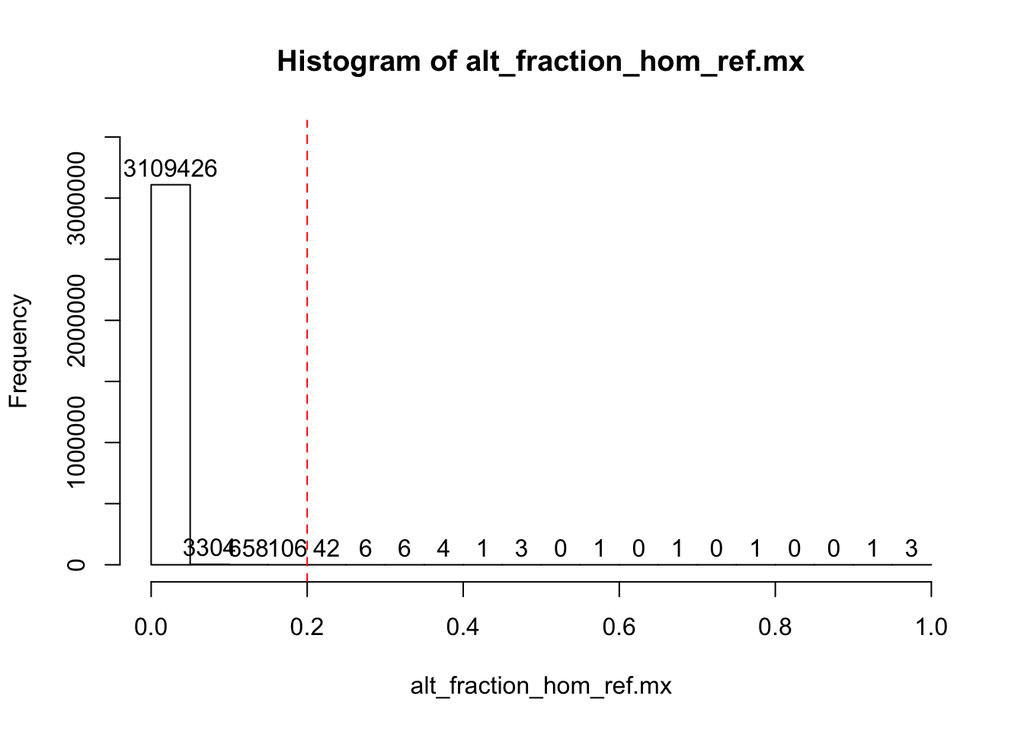

```r
hist(alt_fraction_hom_ref.mx, xlim=c(0,1), lab=T, ylim=c(0,35e5))
abline(v=alt.fr.lo, lty=2, col="red")
```

```r
sum(alt_fraction_hom_ref.mx > alt.fr.lo, na.rm = T)
```

```
## [1] 69
```

```r
# Explore alt_fraction in het

alt_fraction_het.mx <- alt_fraction.mx
NA -> alt_fraction_het.mx[gt.mx != 1]
sum(!is.na(alt_fraction_het.mx))
```

```
## [1] 122031
```

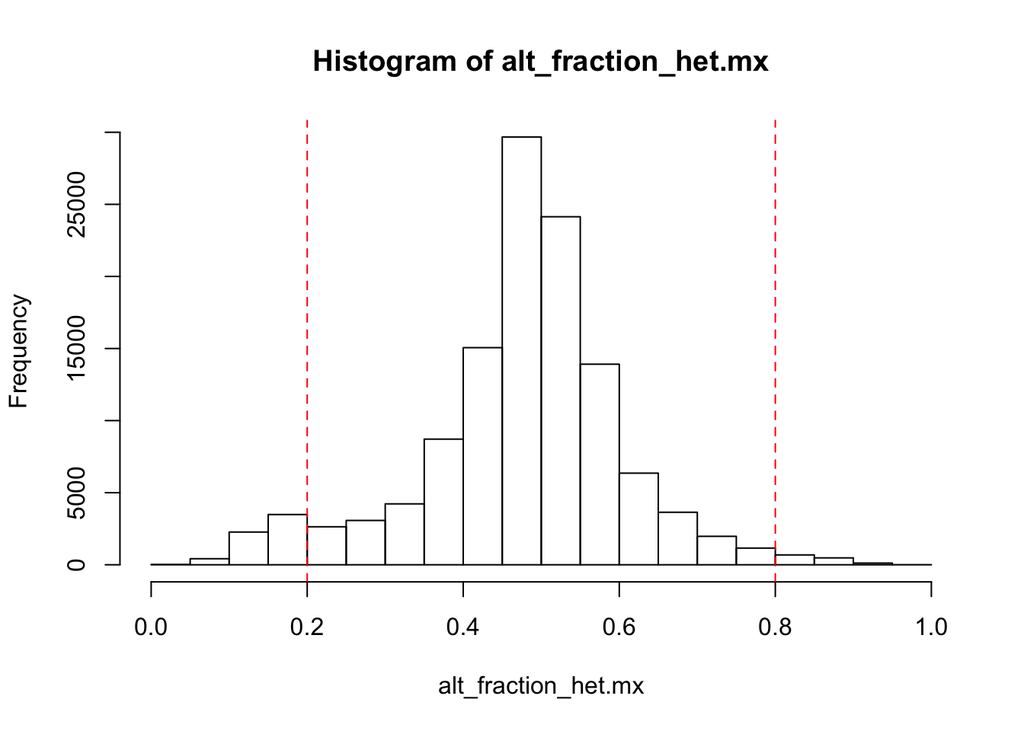

```r
hist(alt_fraction_het.mx, xlim=c(0,1))
abline(v=alt.fr.lo, lty=2, col="red")
abline(v=alt.fr.hi, lty=2, col="red")
```

```r
sum(alt_fraction_het.mx < alt.fr.lo, na.rm = T)
```

```
## [1] 5523
```

```r
sum(alt_fraction_het.mx > alt.fr.hi, na.rm = T)
```

```
## [1] 1282
```

```r
# Explore alt_fraction in hom.alt

alt_fraction_hom_alt.mx <- alt_fraction.mx
NA -> alt_fraction_hom_alt.mx[gt.mx != 2]
sum(!is.na(alt_fraction_hom_alt.mx))
```

```
## [1] 61070
```

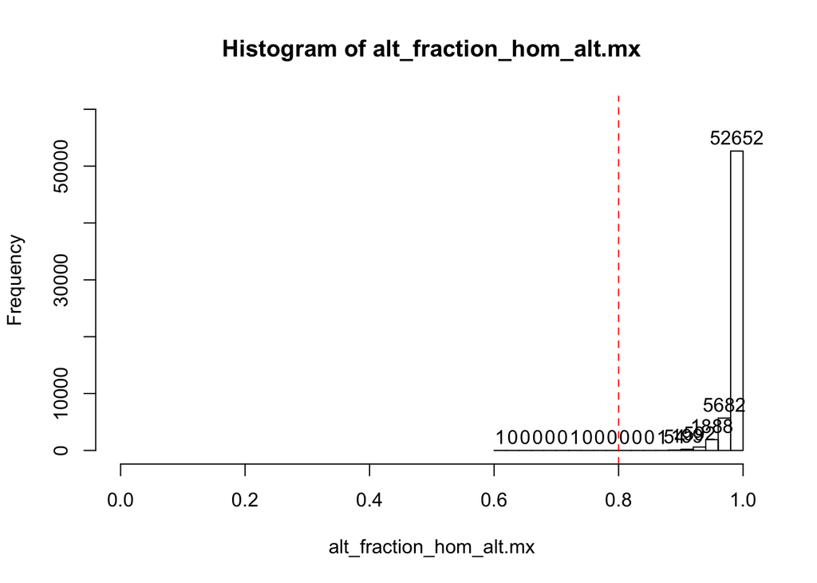

```r
hist(alt_fraction_hom_alt.mx, xlim=c(0,1), lab=T, ylim=c(0,60e3))
abline(v=alt.fr.hi, lty=2, col="red")
```

```r
sum(alt_fraction_hom_alt.mx < alt.fr.hi, na.rm = T)
```

```
## [1] 2
```

```r
# Clean-up (keep matrices needed in teh next chunk!)
rm(alt_fraction.mx)
```

## 8.2 Update genotypes matrix

```r
NA -> gt.mx[alt_fraction_hom_ref.mx > alt.fr.lo]
NA -> gt_chr.mx[alt_fraction_hom_ref.mx > alt.fr.lo]

NA -> gt.mx[alt_fraction_het.mx > alt.fr.hi]
NA -> gt_chr.mx[alt_fraction_het.mx > alt.fr.hi]

NA -> gt.mx[alt_fraction_het.mx < alt.fr.lo]
NA -> gt_chr.mx[alt_fraction_het.mx < alt.fr.lo]

NA -> gt.mx[alt_fraction_hom_alt.mx < alt.fr.hi]
NA -> gt_chr.mx[alt_fraction_hom_alt.mx < alt.fr.hi]

rm(alt_fraction_hom_ref.mx, alt_fraction_het.mx, alt_fraction_hom_alt.mx)
```

## 8.3 Repeat assessment of allelic fractions in Hom-Ref, Het and Hom-Alt

```r
# Prepare alt_fraction.mx
alt_fraction.mx <- alt.mx / (alt.mx + ref.mx)
dim(alt_fraction.mx)
```

```
## [1] 7762  541
```

```r
sum(is.na(alt_fraction.mx))
```

```
## [1] 117863
```

```r
sum(is.na(gt.mx))
```

```
## [1] 909454
```

```r
# Only consider alt_fraction, where genotypes are not NA
NA -> alt_fraction.mx[is.na(gt.mx)]

sum(is.na(alt_fraction.mx))
```

```
## [1] 909454
```

```r
sum(is.na(gt.mx))
```

```
## [1] 909454
```

```r
# Explore alt_fraction in hom.ref

alt_fraction_hom_ref.mx <- alt_fraction.mx
NA -> alt_fraction_hom_ref.mx[gt.mx != 0]
sum(!is.na(alt_fraction_hom_ref.mx))
```

```
## [1] 3113494
```

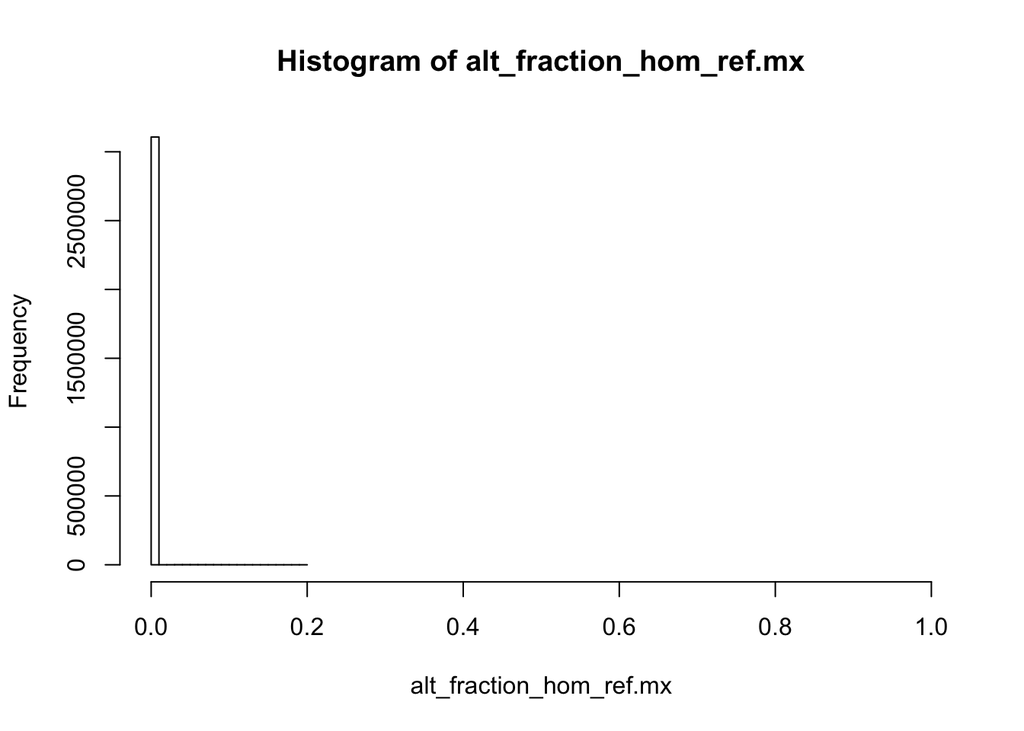

```r
hist(alt_fraction_hom_ref.mx, xlim=c(0,1))
```

```r
sum(alt_fraction_hom_ref.mx > alt.fr.lo, na.rm = T)
```

```
## [1] 0
```

```r
# Explore alt_fraction in het

alt_fraction_het.mx <- alt_fraction.mx
NA -> alt_fraction_het.mx[gt.mx != 1]
sum(!is.na(alt_fraction_het.mx))
```

```
## [1] 115226
```

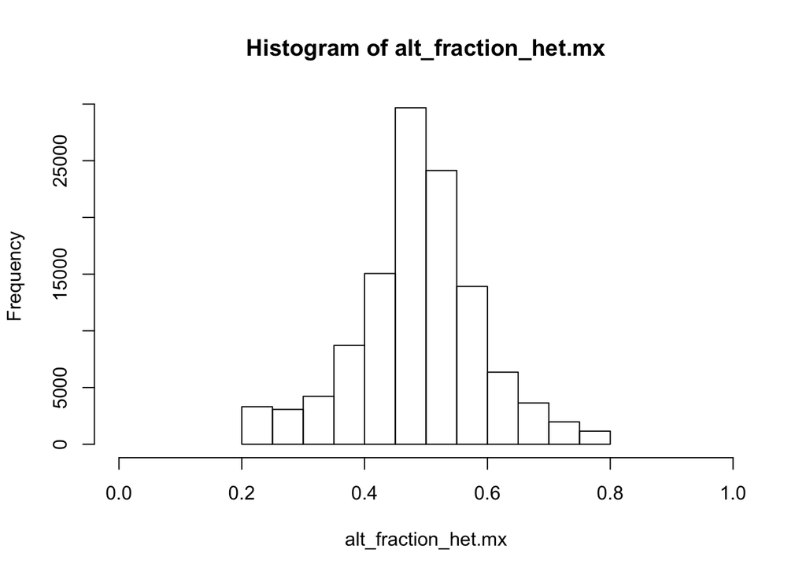

```r
hist(alt_fraction_het.mx, xlim=c(0,1))
```

```r
sum(alt_fraction_het.mx < alt.fr.lo, na.rm = T)
```

```
## [1] 0
```

```r
sum(alt_fraction_het.mx > alt.fr.hi, na.rm = T)
```

```
## [1] 0
```

```r
# Explore alt_fraction in hom.alt

alt_fraction_hom_alt.mx <- alt_fraction.mx
NA -> alt_fraction_hom_alt.mx[gt.mx != 2]
sum(!is.na(alt_fraction_hom_alt.mx))
```

```
## [1] 61068
```

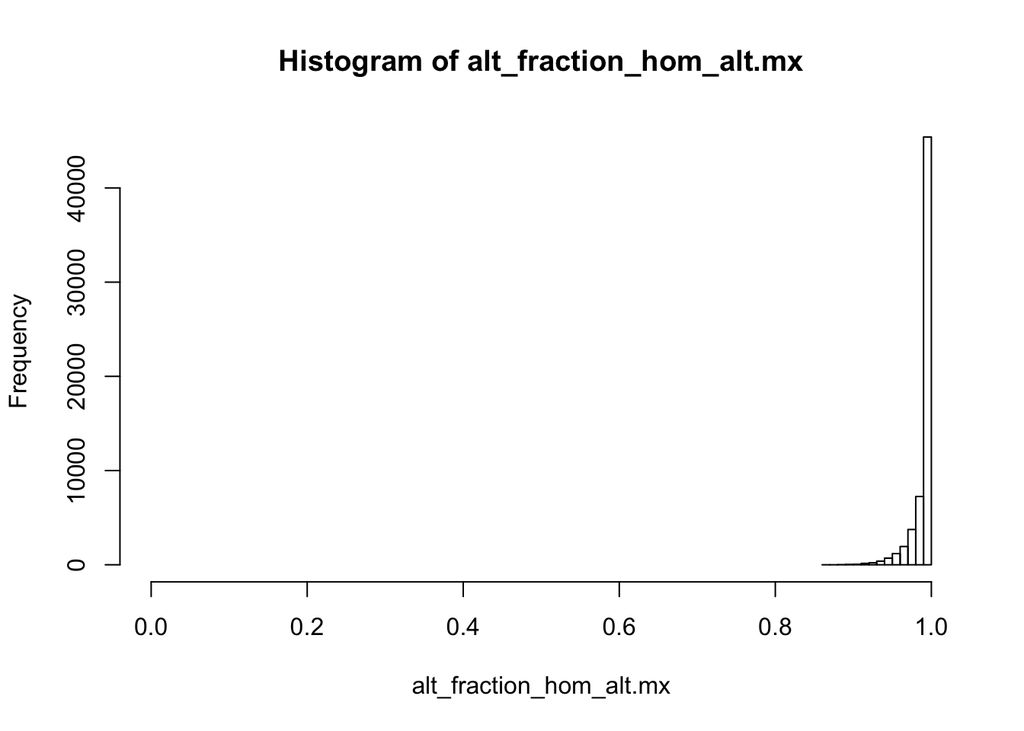

```r
hist(alt_fraction_hom_alt.mx, xlim=c(0,1))
```

```r
sum(alt_fraction_hom_alt.mx < alt.fr.hi, na.rm = T)
```

```
## [1] 0
```

```r
# Clean-up
rm(alt_fraction.mx, alt_fraction_hom_ref.mx, alt_fraction_het.mx,
   alt_fraction_hom_alt.mx, ref.mx, alt.mx, alt.fr.lo, alt.fr.hi)
```

# 9 Explore data after gq_dp_af filtering

```r
# Fraction of NA genotypes after gq-dp-af filtering
sum(is.na(gt.mx))/(nrow(gt.mx)*ncol(gt.mx)) # ~22%
```

```
## [1] 0.2165758
```

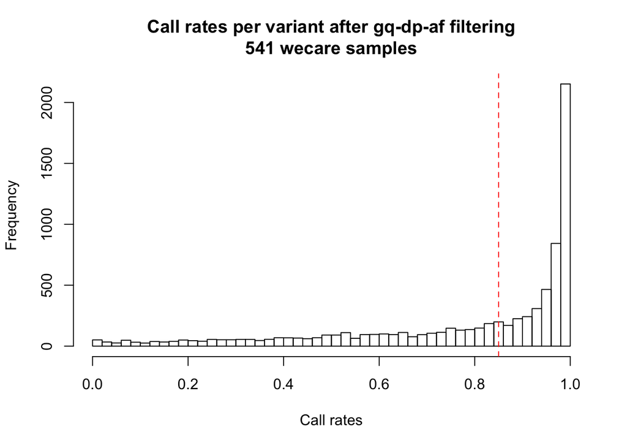

```r
# Call rates per variant after gq-dp-af filtering
x <- apply(gt.mx,1,call_rate.udf)
hist(x, breaks=50, main="Call rates per variant after gq-dp-af filtering\n541 wecare samples", xlab="Call rates")
abline(v=min.call.rate, lty=2, col="red")
```

```r
sum(x < min.call.rate)
```

```
## [1] 3247
```

```r
sum(x < min.call.rate)/length(x) # Fraction of variants failing below the cut-off
```

```
## [1] 0.41832
```

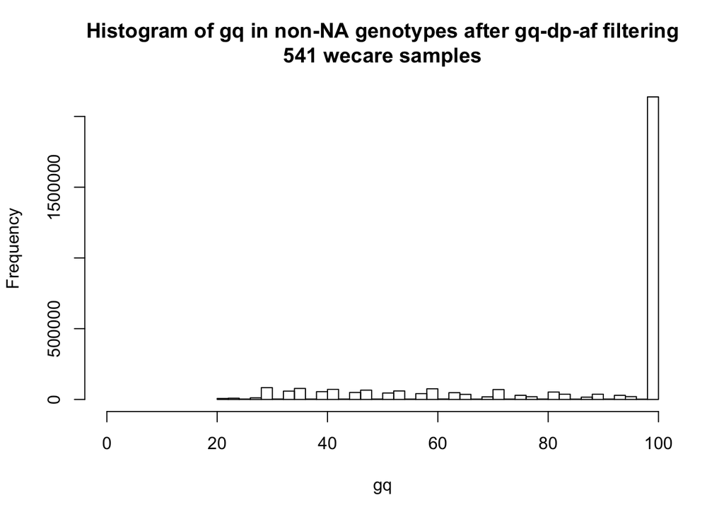

```r
# gq  after gq-dp-af filtering (when gt is not NA !)
hist(gq.mx[!is.na(gt.mx)], breaks=50, xlim=c(0,100),
     main="Histogram of gq in non-NA genotypes after gq-dp-af filtering\n541 wecare samples", xlab="gq")
```

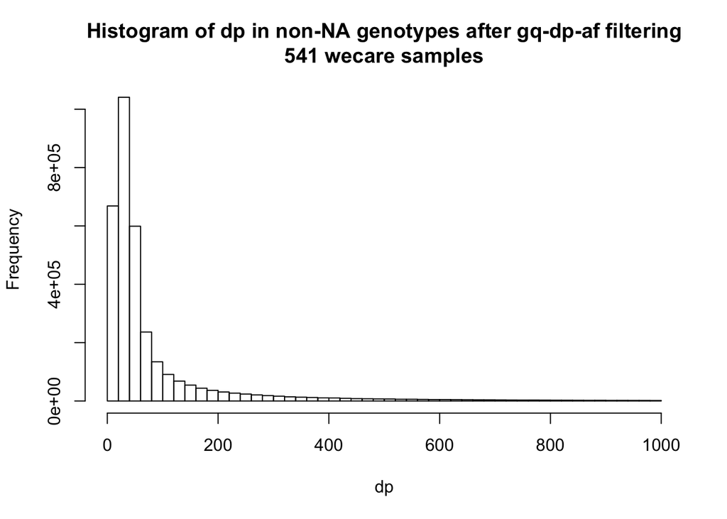

```r
# dp after gq-dp-af filtering (when gt is not NA !)
hist(dp.mx[!is.na(gt.mx)], breaks=50,
     main="Histogram of dp in non-NA genotypes after gq-dp-af filtering\n541 wecare samples", xlab="dp")
```

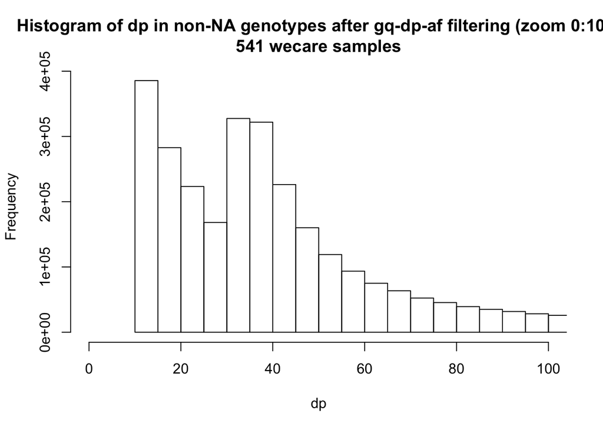

```r
hist(dp.mx[!is.na(gt.mx)], breaks=250, xlim=c(0,100),
     main="Histogram of dp in non-NA genotypes after gq-dp-af filtering (zoom 0:100)\n541 wecare samples", xlab="dp")
```

```r
# Mean GQ and DP in non-NA genotypes after gq-dp-af filtering
mean(gq.mx[!is.na(gt.mx)], na.rm=TRUE) # ~ 84
```

```
## [1] 84.00038
```

```r
mean(dp.mx[!is.na(gt.mx)], na.rm=TRUE) # ~ 83
```

```
## [1] 83.35945
```

```r
# Clean-up
rm(x)
```

# 10 Filter variants by final call rate

Remove variants with call rate < 85% after the genotypes filtering:  
removes 3,247 (~42%) variants (7,762 -> 4,515)

```r
dim(gt.mx)
```

```
## [1] 7762  541
```

```r
# Estimate callrates
x <- apply(gt.mx, 1, call_rate.udf)
length(x)
```

```
## [1] 7762
```

```r
x[1:7]
```

```
## Var000000001 Var000000003 Var000000004 Var000000005 Var000000006 Var000000010 Var000000011
##    0.9889094    0.9426987    0.7338262    0.5730129    0.7707948    0.9020333    0.9149723
```

```r
# Make index for filteirng
var.retained <- x >= min.call.rate
sum(var.retained) # 4,515 to be retained
```

```
## [1] 4515
```

```r
1 - sum(var.retained)/nrow(gt.mx) # ~42% to be removed
```

```
## [1] 0.41832
```

```r
# Remove variants with loaw call rates
gt.mx <- gt.mx[ var.retained, ]
gt_chr.mx <- gt_chr.mx[ var.retained, ]

dp.mx <- dp.mx[ var.retained, ]
gq.mx <- gq.mx[ var.retained, ]
fixed.df <- fixed.df[ var.retained, ]

# Clean-up
rm(x, var.retained)
```

# 11 Remove non-polymorphic sites

Remove 746 sites: 4,515 -> 3,769

```r
# Function to detect uniform numeric vector
uniformity_check.udf <- function(x){
  if (all(is.na(x))){"All_NA"}
  else if (min(x,na.rm=T)==max(x,na.rm=T)){"Uniform"}
  else {"Non-Uniform"}}

# Make the filter
uniformity_check <- apply(gt.mx,1,uniformity_check.udf)
summary(as.factor(uniformity_check))
```

```
## Non-Uniform     Uniform
##        3769         746
```

```r
non_uniform_sites <- uniformity_check == "Non-Uniform"

# Remove variants with uniform genotypes accross all samples
gt.mx <- gt.mx[non_uniform_sites,]
gt_chr.mx <- gt_chr.mx[non_uniform_sites,]
gq.mx <- gq.mx[non_uniform_sites,]
dp.mx <- dp.mx[non_uniform_sites,]

fixed.df <- fixed.df[non_uniform_sites,]

dim(gt.mx)
```

```
## [1] 3769  541
```

```r
dim(gt_chr.mx)
```

```
## [1] 3769  541
```

```r
dim(gq.mx)
```

```
## [1] 3769  541
```

```r
dim(dp.mx)
```

```
## [1] 3769  541
```

```r
dim(fixed.df)
```

```
## [1] 3769  110
```

```r
# Clean-up
rm(uniformity_check.udf, uniformity_check, non_uniform_sites)
```

# 12 Explore data after filtering

Genotypes NA rates  
Histogram of call rates per variant  
Histograms of gq and dp in non-NA genotypes

```r
# Fraction of NA genotypes after filtering
sum(is.na(gt.mx))/(nrow(gt.mx)*ncol(gt.mx)) # ~3.8%
```

```
## [1] 0.03779446
```

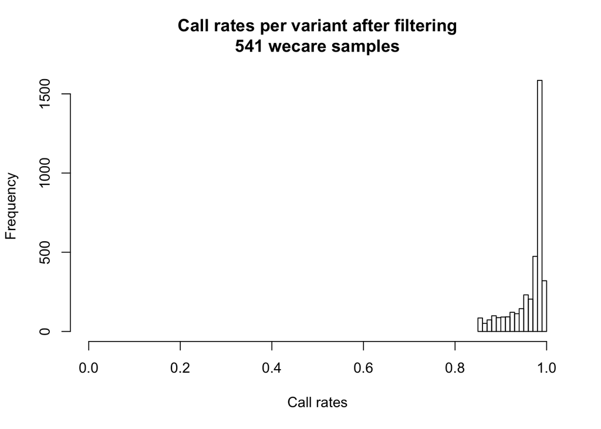

```r
# Call rates per variant after filtering
x <- apply(gt.mx,1,call_rate.udf)
hist(x, main="Call rates per variant after filtering\n541 wecare samples",
     xlim=c(0,1), xlab="Call rates")
```

```r
sum(x < min.call.rate)
```

```
## [1] 0
```

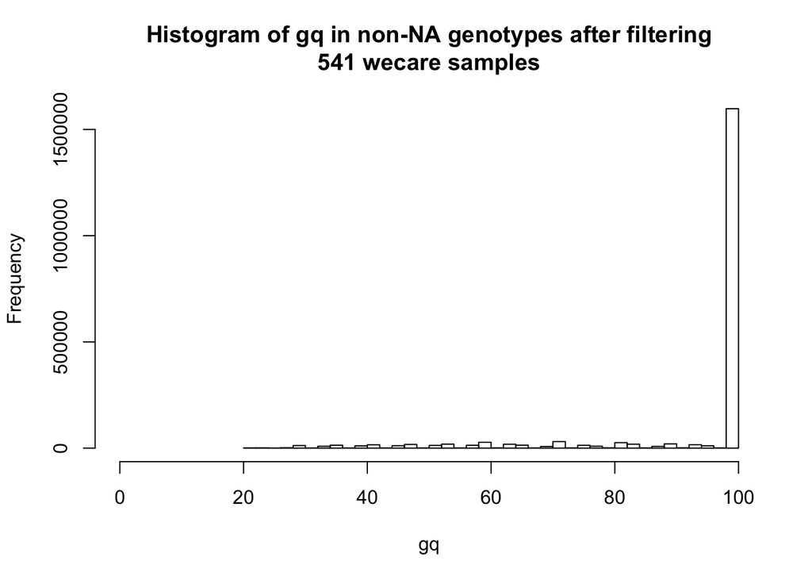

```r
# gq  after filtering (when gt is not NA !)
hist(gq.mx[!is.na(gt.mx)], breaks=50, xlim=c(0,100),
     main="Histogram of gq in non-NA genotypes after filtering\n541 wecare samples", xlab="gq")
```

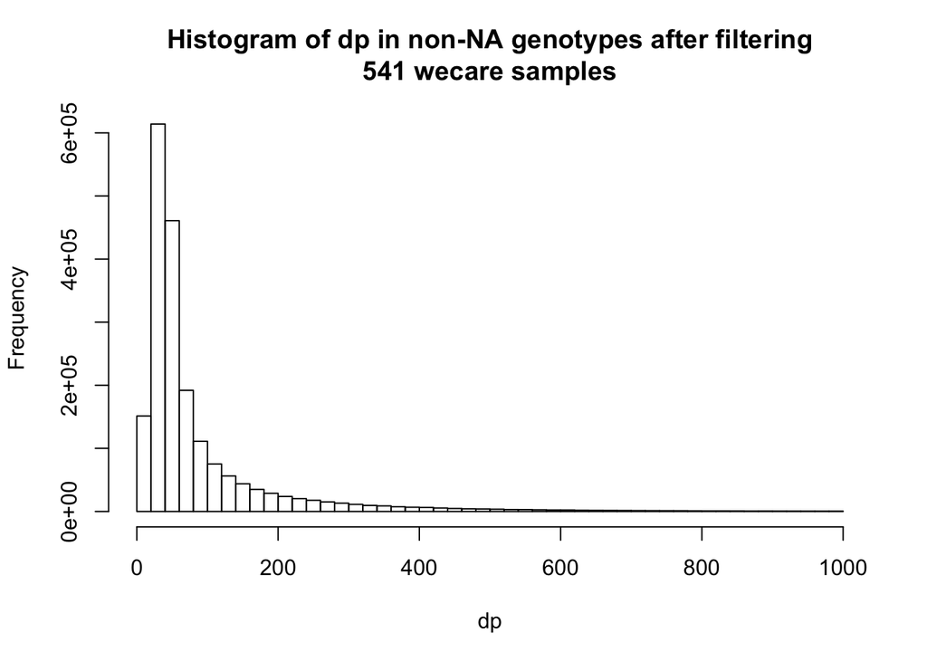

```r
# dp after filtering (when gt is not NA !)
hist(dp.mx[!is.na(gt.mx)], breaks=50,
     main="Histogram of dp in non-NA genotypes after filtering\n541 wecare samples", xlab="dp")
```

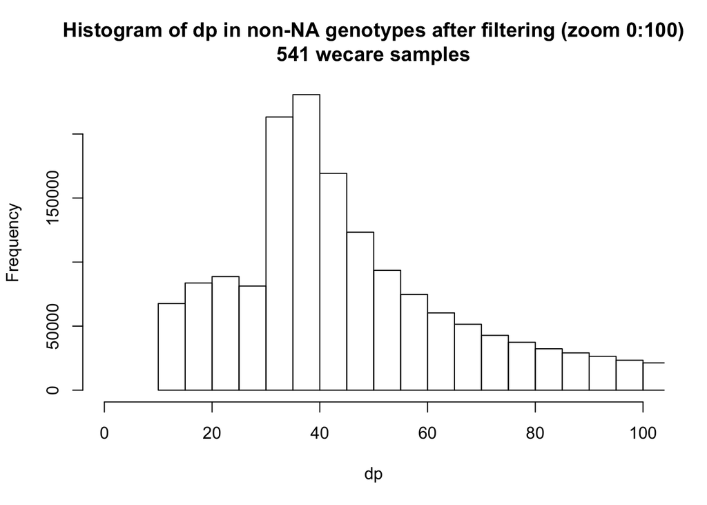

```r
hist(dp.mx[!is.na(gt.mx)], breaks=250, xlim=c(0,100),
     main="Histogram of dp in non-NA genotypes after filtering (zoom 0:100)\n541 wecare samples", xlab="dp")
```

```r
# Mean GQ and DP in non-NA genotypes after filtering
mean(gq.mx[!is.na(gt.mx)], na.rm=TRUE) # ~ 93
```

```
## [1] 92.54247
```

```r
mean(dp.mx[!is.na(gt.mx)], na.rm=TRUE) # ~ 88
```

```
## [1] 88.4309
```

```r
quantile(gq.mx[!is.na(gt.mx)], na.rm=TRUE)
```

```
##   0%  25%  50%  75% 100%
##   20   99   99   99   99
```

```r
quantile(dp.mx[!is.na(gt.mx)], na.rm=TRUE)
```

```
##   0%  25%  50%  75% 100%
##   10   35   47   89 1000
```

```r
# Clean-up (keep dp for later comparison of samples)
rm(x, min.call.rate, gq.mx, call_rate.udf)
```

# 13 Data summary

```r
ls()
```

```
## [1] "base_folder"    "data_folder"    "dp.mx"          "fixed.df"       "gt_chr.mx"      "gt.mx"          "scripts_folder"
```

```r
dim(gt.mx)
```

```
## [1] 3769  541
```

```r
dim(gt_chr.mx)
```

```
## [1] 3769  541
```

```r
dim(dp.mx)
```

```
## [1] 3769  541
```

```r
dim(fixed.df)
```

```
## [1] 3769  110
```

```r
# Check consistence of rownames
sum(rownames(gt.mx) != rownames(gt_chr.mx))
```

```
## [1] 0
```

```r
sum(rownames(gt.mx) != rownames(dp.mx))
```

```
## [1] 0
```

```r
sum(colnames(gt.mx) != colnames(gt_chr.mx))
```

```
## [1] 0
```

```r
sum(colnames(gt.mx) != colnames(dp.mx))
```

```
## [1] 0
```

```r
sum(rownames(gt.mx) != rownames(fixed.df))
```

```
## [1] 0
```

# 14 Save data

```r
save.image(file.path(data_folder, "r02_filter_genotypes.RData"))
```

# 15 Final section

```r
ls()
```

```
## [1] "base_folder"    "data_folder"    "dp.mx"          "fixed.df"       "gt_chr.mx"      "gt.mx"          "scripts_folder"
```

```r
Sys.time()
```

```
## [1] "2021-02-27 17:52:33 GMT"
```

```r
gc()
```

```
##           used (Mb) gc trigger  (Mb) limit (Mb) max used  (Mb)
## Ncells  517782 27.7     865952  46.3         NA   865952  46.3
## Vcells 7524620 57.5   56641693 432.2      16384 70801745 540.2
```